# Week7_21022008_NguyenHuuTho (1)

```python
!pip install opencv-python
!pip install opencv-contrib-python
```

[output not shown]

[output not shown]

Để sử dụng thuật toán SIFT (Scale-Invariant Feature Transform) trong thị giác máy tính, bạn có thể tham khảo mã nguồn Python sau đây sử dụng thư viện OpenCV. Thuật toán SIFT giúp trích xuất đặc trưng từ hình ảnh một cách bất biến với tỉ lệ và xoay, rất hữu ích trong các bài toán nhận dạng và so khớp hình ảnh.

### Cài đặt Thư Viện

Đảm bảo bạn đã cài đặt OpenCV cho Python. Nếu chưa, bạn có thể cài đặt bằng pip:

```
pip install opencv-python
pip install opencv-contrib-python
```

### Mã nguồn minh họa SIFT

```
import cv2
import matplotlib.pyplot as plt

# Đọc hình ảnh
image = cv2.imread('duong_dan_toi_anh.jpg')
gray_image = cv2.cvtColor(image, cv2.COLOR_BGR2GRAY)

# Khởi tạo SIFT detector
sift = cv2.SIFT_create()

# Tìm key points và descriptors với SIFT
keypoints, descriptors = sift.detectAndCompute(gray_image, None)

# Vẽ key points lên hình ảnh
img_with_keypoints = cv2.drawKeypoints(gray_image, keypoints, image)

# Hiển thị hình ảnh
plt.imshow(img_with_keypoints)
plt.show()

# In số lượng key points được tìm thấy
print(f"Số lượng key points: {len(keypoints)}")
```

### Giải thích cú pháp và các tham số

- `cv2.SIFT_create()`: Khởi tạo một đối tượng SIFT. Bạn có thể truyền các tham số như `nfeatures` để chỉ định số lượng đặc trưng tối đa được trả về.
- `sift.detectAndCompute(image, mask)`: Phương thức này tìm các key points và tính toán descriptors cho hình ảnh. Tham số `image` là hình ảnh đầu vào và `mask` là một mặt nạ để chỉ định khu vực của hình ảnh để phát hiện (None nếu không sử dụng mặt nạ).
- `cv2.drawKeypoints(image, keypoints, outImage)`: Hàm này vẽ các key points đã tìm được lên hình ảnh. `image` là hình ảnh đầu vào, `keypoints` là danh sách các key points, và `outImage` là hình ảnh kết quả sẽ hiển thị các key points.

### Thay đổi giá trị tham số

Bạn có thể thay đổi các tham số của `cv2.SIFT_create()` để xem sự thay đổi về số lượng và chất lượng các key points được tìm thấy. Ví dụ, giảm `nfeatures` xuống còn 50 để giới hạn số lượng đặc trưng tối đa được phát hiện:

```
sift = cv2.SIFT_create(nfeatures=50)
```

Hãy chắc chắn rằng đường dẫn đến hình ảnh là đúng và hình ảnh đó hợp lệ để code có thể chạy mà không gặp lỗi.

Trong OpenCV, có nhiều giải thuật và hàm hỗ trợ cho việc so khớp đặc trưng (feature matching) giữa các hình ảnh. Hai phương pháp phổ biến là sử dụng Brute-Force Matcher và FLANN based Matcher. Tôi sẽ giới thiệu về cả hai phương pháp này và cách sử dụng chúng để so khớp các đặc trưng được trích xuất bởi SIFT.

### 1. Brute-Force Matcher

Brute-Force Matcher là phương pháp đơn giản nhất để so khớp đặc trưng. Nó so sánh mọi descriptor trong một tập hợp với mọi descriptor trong tập hợp khác để tìm ra các cặp đặc trưng tốt nhất.

#### Các hàm hỗ trợ:

- `cv2.BFMatcher(normType, crossCheck)`: Tạo một Brute-Force matcher. `normType` chỉ định khoảng cách để so sánh (thường là `cv2.NORM_L2` cho SIFT và SURF, `cv2.NORM_HAMMING` cho ORB và BRIEF). `crossCheck=True` chỉ định rằng chỉ những cặp đặc trưng mà mỗi bên là tốt nhất của bên kia mới được trả về.

#### Ví dụ minh họa:

```
import cv2
import matplotlib.pyplot as plt

# Đọc hai hình ảnh
img1 = cv2.imread('image1.jpg', cv2.IMREAD_GRAYSCALE)
img2 = cv2.imread('image2.jpg', cv2.IMREAD_GRAYSCALE)

# Khởi tạo SIFT và tìm key points và descriptors
sift = cv2.SIFT_create()
kp1, des1 = sift.detectAndCompute(img1, None)
kp2, des2 = sift.detectAndCompute(img2, None)

# Khởi tạo Brute-Force matcher và thực hiện so khớp
bf = cv2.BFMatcher(cv2.NORM_L2, crossCheck=True)
matches = bf.match(des1, des2)

# Sắp xếp các matches theo khoảng cách
matches = sorted(matches, key=lambda x: x.distance)

# Vẽ các kết quả so khớp
img_matches = cv2.drawMatches(img1, kp1, img2, kp2, matches[:50], None, flags=2)

# Hiển thị hình ảnh
plt.imshow(img_matches)
plt.show()
```

### 2. FLANN Based Matcher

FLANN (Fast Library for Approximate Nearest Neighbors) là một phương pháp tối ưu hóa việc tìm kiếm gần nhất, nhanh hơn Brute-Force khi làm việc với lượng lớn dữ liệu.

#### Các hàm hỗ trợ:

- `cv2.FlannBasedMatcher(index_params, search_params)`: Tạo một FLANN matcher. `index_params` và `search_values` là các tham số cấu hình cho thuật toán tìm kiếm.

#### Ví dụ minh họa:

```
import numpy as np

# Cấu hình cho SIFT và FLANN
index_params = dict(algorithm=1, trees=5)
search_params = dict(checks=50)

# Khởi tạo FLANN matcher và thực hiện so khớp
flann = cv2.FlannBasedMatcher(indexParams, search_params)
matches = flann.knnMatch(des1, des2, k=2)

# Áp dụng Low's ratio test
good_matches = []
for m, n in matches:
    if m.distance < 0.75 * n.distance:
        good_matches.append(m)

# Vẽ các kết quả so khớp
img_matches = cv2.drawMatchesKnn(img1, kp1, img2, kp2, [good_matches], None, flags=2)

# Hiển thị hình ảnh
plt.imshow(img_matches)
plt.show()
```

Thuật toán tạo ảnh toàn cảnh trong OpenCV sử dụng một loạt các bước bao gồm phát hiện đặc trưng, so khớp đặc trưng, và cuối cùng là ghép các ảnh lại để tạo thành ảnh toàn cảnh. OpenCV cung cấp một lớp tiện ích có tên là `Stitcher` để tự động hóa quá trình này.

### Thuật toán Tạo Ảnh Toàn Cảnh:

1. **Phát hiện Đặc trưng**: Đầu tiên, thuật toán phát hiện các đặc trưng trong mỗi ảnh. Các đặc trưng này là các điểm đáng chú ý có thể được so sánh một cách đáng tin cậy giữa các ảnh khác nhau.
2. **So Khớp Đặc trưng**: Sau khi phát hiện đặc trưng, thuật toán tìm kiếm các đặc trưng tương đồng giữa các cặp ảnh. Điều này cho phép thuật toán xác định các mối liên kết giữa các ảnh.
3. **Ước tính Biến đổi (Homography)**: Dựa trên các đặc trưng đã được ghép nối, thuật toán ước tính một mô hình biến đổi để căn chỉnh và biến đổi các ảnh sao cho chúng ghép khít với nhau.
4. **Ghép Ảnh**: Các ảnh được biến đổi sau đó được ghép lại để tạo thành ảnh toàn cảnh cuối cùng.

### Cú Pháp Các Hàm Được Sử Dụng:

OpenCV cung cấp lớp `Stitcher` để tạo ảnh toàn cảnh. Cú pháp cơ bản:

```
cv2.Stitcher_create(mode=cv2.Stitcher_PANORAMA)
```

- `mode`: Chế độ của Stitcher, thường là `cv2.Stitcher_PANORAMA` (dành cho ảnh ngang) hoặc `cv2.Stitcher_SCANS` (dành cho ảnh dọc).

#### Ví dụ Minh Họa:

Dưới đây là đoạn code Python mẫu để tạo ảnh toàn cảnh từ hai hoặc nhiều ảnh.

```
import cv2
import numpy as np

def create_panorama(images, show_matches=False):
    # Khởi tạo đối tượng Stitcher
    stitcher = cv2.Stitcher_create(cv2.Stitcher_PANORAMA)

    # Ghép các ảnh và lấy kết quả
    (status, panorama) = stitcher.stitch(images)

    if status == cv2.Stitcher_OK:
        # Hiển thị ảnh toàn cảnh
        cv2.imshow("Panorama", panorama)
        cv2.waitKey(0)
        cv2.destroyAllWindows()
    else:
        print("Không thể tạo ảnh toàn cảnh, lỗi:", status)

# Đọc các ảnh
img1 = cv2.imread('path_to_image1.jpg')
img2 = cv2.imread('path_to_image2.jpg')

# Tạo ảnh toàn cảnh
create_panorama([img1, img2])
```

Trong ví dụ trên, các ảnh được đọc và đưa vào hàm `create_panorama`, sử dụng đối tượng `Stitcher` để ghép chúng lại. Nếu quá trình thành công, ảnh toàn cảnh sẽ được hiển thị. Nếu không, chương trình sẽ in ra mã lỗi. Đảm bảo các đường dẫn đến ảnh là chính xác và các ảnh phải có chiều cao tương tự nhau để kết quả ghép có chất lượng tốt.

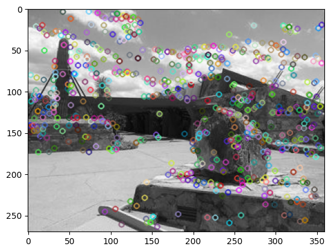

```
Số lượng key points: 637
```

```python
import cv2
import matplotlib.pyplot as plt

# Đọc hình ảnh
image = cv2.imread('panorama3.jpg')
# image = cv2.imread('panorama4.jpg')
gray_image = cv2.cvtColor(image, cv2.COLOR_BGR2GRAY)

# Khởi tạo SIFT detector
sift = cv2.SIFT_create()

# Tìm key points và descriptors với SIFT
keypoints, descriptors = sift.detectAndCompute(gray_image, None)

# Vẽ key points lên hình ảnh
img_with_keypoints = cv2.drawKeypoints(gray_image, keypoints, image)

# Hiển thị hình ảnh
plt.imshow(img_with_keypoints)
plt.show()

# In số lượng key points được tìm thấy
print(f"Số lượng key points: {len(keypoints)}")
```

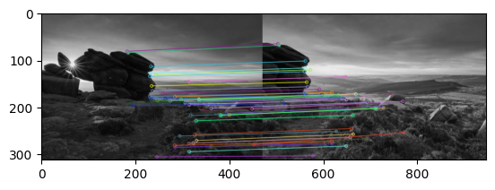

```python
import cv2
import matplotlib.pyplot as plt

# Đọc hai hình ảnh
img1 = cv2.imread('Panorama1.jpg', cv2.IMREAD_GRAYSCALE)
img2 = cv2.imread('Panorama2.jpg', cv2.IMREAD_GRAYSCALE)

# Khởi tạo SIFT và tìm key points và descriptors
sift = cv2.SIFT_create()
kp1, des1 = sift.detectAndCompute(img1, None)
kp2, des2 = sift.detectAndCompute(img2, None)

# Khởi tạo Brute-Force matcher và thực hiện so khớp
bf = cv2.BFMatcher(cv2.NORM_L2, crossCheck=True)
matches = bf.match(des1, des2)

# Sắp xếp các matches theo khoảng cách
matches = sorted(matches, key=lambda x: x.distance)

# Vẽ các kết quả so khớp
img_matches = cv2.drawMatches(img1, kp1, img2, kp2, matches[:50], None, flags=2)

# Hiển thị hình ảnh
plt.imshow(img_matches)
plt.show()
```

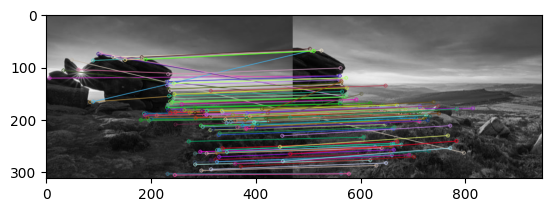

```python
import numpy as np

# Cấu hình cho SIFT và FLANN
index_params = dict(algorithm=1, trees=5)  # Sử dụng thuật toán k-d tree
search_params = dict(checks=50)  # Số lượng vòng lặp thuật toán, giá trị càng lớn thì kết quả càng chính xác nhưng tốn thời gian hơn

# Khởi tạo FLANN matcher và thực hiện so khớp
flann = cv2.FlannBasedMatcher(index_params, search_params)
matches = flann.knnMatch(des1, des2, k=2)

# Áp dụng Low's ratio test
good_matches = []
for m, n in matches:
    if m.distance < 0.75 * n.distance:
        good_matches.append(m)

# Vẽ các kết quả so khớp
img_matches = cv2.drawMatchesKnn(img1, kp1, img2, kp2, [good_matches], None, flags=2)

# Hiển thị hình ảnh
plt.imshow(img_matches)
plt.show()
```

```python
import cv2
import numpy as np

def create_panorama(images, show_matches=False):
    # Khởi tạo đối tượng Stitcher
    stitcher = cv2.Stitcher_create(cv2.Stitcher_PANORAMA)

    # Ghép các ảnh và lấy kết quả
    (status, panorama) = stitcher.stitch(images)

    if status == cv2.Stitcher_OK:
        # Hiển thị ảnh toàn cảnh
        cv2.imshow("Panorama", panorama)
        cv2.waitKey(0)
        cv2.destroyAllWindows()
    else:
        print("Không thể tạo ảnh toàn cảnh, lỗi:", status)

# Đọc các ảnh
img1 = cv2.imread('panorama1.jpg')
img2 = cv2.imread('panorama2.jpg')

# Tạo ảnh toàn cảnh
create_panorama([img1, img2])
```

```python
import cv2
import numpy as np

def create_panorama(images, show_matches=False):
    # Khởi tạo đối tượng Stitcher
    stitcher = cv2.Stitcher_create(cv2.Stitcher_PANORAMA)

    # Ghép các ảnh và lấy kết quả
    (status, panorama) = stitcher.stitch(images)

    if status == cv2.Stitcher_OK:
        # Hiển thị ảnh toàn cảnh
        cv2.imshow("Panorama", panorama)
        cv2.waitKey(0)
        cv2.destroyAllWindows()
    else:
        print("Không thể tạo ảnh toàn cảnh, lỗi:", status)

# Đọc các ảnh
img1 = cv2.imread('anh1.jpg')
img2 = cv2.imread('anh2.jpg')

# Tạo ảnh toàn cảnh
create_panorama([img1, img2])
```

```
Không thể tạo ảnh toàn cảnh, lỗi: 1
```

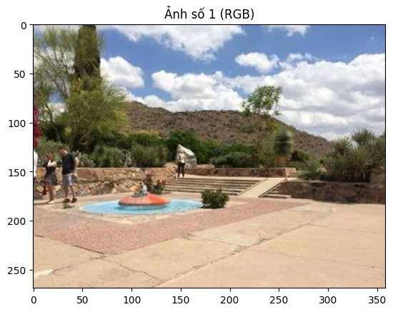

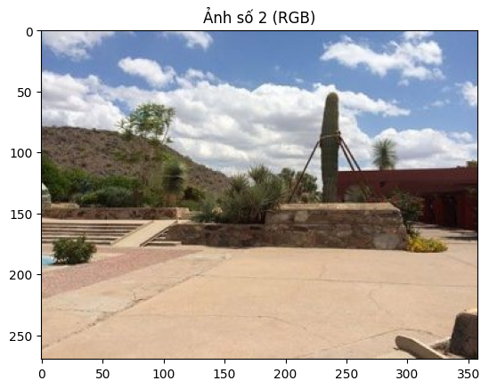

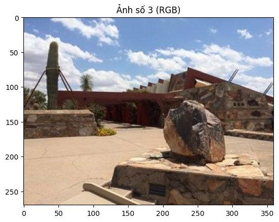

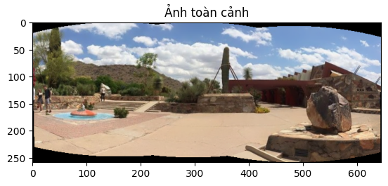

```python
import cv2
import numpy as np
import matplotlib.pyplot as plt

# Đọc ảnh
img1 = cv2.imread('panorama4.jpg')
img2 = cv2.imread('panorama5.jpg')
img3 = cv2.imread('panorama3.jpg')

# Danh sách ảnh và kiểm tra tải thành công
images = [img1, img2, img3]
all_images_loaded = True  # Giả sử tất cả ảnh được tải thành công

for i, img in enumerate(images, start=1):
    if img is None:
        print(f"Không thể tải ảnh số {i}")
        all_images_loaded = False
    else:
        # Chuyển đổi sang RGB để hiển thị bằng Matplotlib
        images[i-1] = cv2.cvtColor(img, cv2.COLOR_BGR2RGB)
        plt.imshow(images[i-1])
        plt.title(f'Ảnh số {i} (RGB)')
        plt.show()

# Chỉ tiếp tục nếu tất cả ảnh đã được tải thành công
if all_images_loaded:
    # Khởi tạo Stitcher
    stitcher = cv2.Stitcher_create()

    # Thực hiện ghép ảnh
    ret, pano = stitcher.stitch(images)

    if ret == cv2.Stitcher_OK:
        # Hiển thị ảnh toàn cảnh
        plt.imshow(pano)
        plt.title('Ảnh toàn cảnh')
        plt.show()
    else:
        print("Ghép ảnh thất bại:", ret)
else:
    print("Một hoặc nhiều ảnh không được tải lên thành công, kiểm tra lại đường dẫn hoặc tên file.")
```

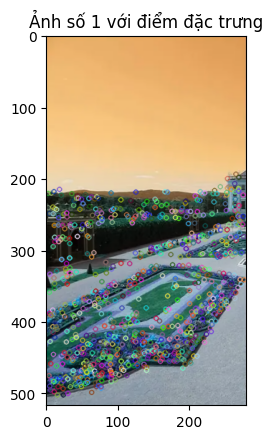

```
Số điểm đặc trưng trong ảnh số 1: 881
```

[figure not shown]

```
Số điểm đặc trưng trong ảnh số 2: 768
```

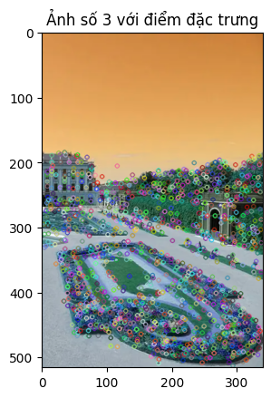

```
Số điểm đặc trưng trong ảnh số 3: 1384
Số matches tốt giữa ảnh 1 và 2: 182
Số matches tốt giữa ảnh 2 và 3: 226
```

[figure not shown]

```python
import cv2
import numpy as np
import matplotlib.pyplot as plt

# Đọc ảnh
img1 = cv2.imread('panorama6.png')
img2 = cv2.imread('panorama7.png')
img3 = cv2.imread('panorama8.png')

# Danh sách ảnh và kiểm tra tải thành công
images = [img1, img2, img3]
all_images_loaded = True  # Giả sử tất cả ảnh được tải thành công

# Sử dụng SIFT để tìm điểm đặc trưng
sift = cv2.SIFT_create()
keypoints = []
descriptors = []

for i, img in enumerate(images, start=1):
    if img is None:
        print(f"Không thể tải ảnh số {i}")
        all_images_loaded = False
    else:
        kp, des = sift.detectAndCompute(img, None)
        keypoints.append(kp)
        descriptors.append(des)
        img_with_kp = cv2.drawKeypoints(img, kp, None)
        plt.imshow(img_with_kp)
        plt.title(f'Ảnh số {i} với điểm đặc trưng')
        plt.show()
        print(f"Số điểm đặc trưng trong ảnh số {i}: {len(kp)}")

# Chỉ tiếp tục nếu tất cả ảnh đã được tải thành công
if all_images_loaded:
    # Sử dụng BFMatcher để so khớp điểm đặc trưng giữa các cặp ảnh
    bf = cv2.BFMatcher()
    for i in range(len(images) - 1):
        matches = bf.knnMatch(descriptors[i], descriptors[i+1], k=2)
        # Áp dụng Low's ratio test
        good = []
        for m, n in matches:
            if m.distance < 0.75 * n.distance:
                good.append(m)
        print(f"Số matches tốt giữa ảnh {i+1} và {i+2}: {len(good)}")

    # Khởi tạo Stitcher với cấu hình tùy chỉnh
    stitcher = cv2.Stitcher_create()
    stitcher.setPanoConfidenceThresh(0.6)  # Điều chỉnh ngưỡng tin cậy

    # Thực hiện ghép ảnh
    ret, pano = stitcher.stitch(images)

    if ret == cv2.Stitcher_OK:
        # Hiển thị ảnh toàn cảnh
        plt.imshow(pano)
        plt.title('Ảnh toàn cảnh')
        plt.show()
    else:
        print("Ghép ảnh thất bại, mã lỗi:", ret)
else:
    print("Một hoặc nhiều ảnh không được tải lên thành công, kiểm tra lại đường dẫn hoặc tên file.")
```

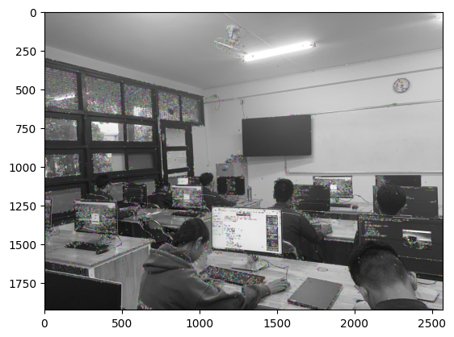

```
Số lượng key points: 13456
```

```python
import cv2
import matplotlib.pyplot as plt

# Đọc hình ảnh
image = cv2.imread('anh1.jpg')
# image = cv2.imread('panorama4.jpg')
gray_image = cv2.cvtColor(image, cv2.COLOR_BGR2GRAY)

# Khởi tạo SIFT detector
sift = cv2.SIFT_create()

# Tìm key points và descriptors với SIFT
keypoints, descriptors = sift.detectAndCompute(gray_image, None)

# Vẽ key points lên hình ảnh
img_with_keypoints = cv2.drawKeypoints(gray_image, keypoints, image)

# Hiển thị hình ảnh
plt.imshow(img_with_keypoints)
plt.show()

# In số lượng key points được tìm thấy
print(f"Số lượng key points: {len(keypoints)}")
```

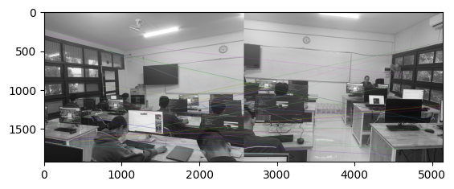

```python
import cv2
import matplotlib.pyplot as plt

# Đọc hai hình ảnh
img1 = cv2.imread('anh1.jpg', cv2.IMREAD_GRAYSCALE)
img2 = cv2.imread('anh2.jpg', cv2.IMREAD_GRAYSCALE)

# Khởi tạo SIFT và tìm key points và descriptors
sift = cv2.SIFT_create()
kp1, des1 = sift.detectAndCompute(img1, None)
kp2, des2 = sift.detectAndCompute(img2, None)

# Khởi tạo Brute-Force matcher và thực hiện so khớp
bf = cv2.BFMatcher(cv2.NORM_L2, crossCheck=True)
matches = bf.match(des1, des2)

# Sắp xếp các matches theo khoảng cách
matches = sorted(matches, key=lambda x: x.distance)

# Vẽ các kết quả so khớp
img_matches = cv2.drawMatches(img1, kp1, img2, kp2, matches[:50], None, flags=2)

# Hiển thị hình ảnh
plt.imshow(img_matches)
plt.show()
```